**Machine Learning for Mechanical Engineering**  
**Homework 05 - Solution**

Instructor: Prof. Seungchul Lee  
http://iai.postech.ac.kr/  
Industrial AI Lab at POSTECH

# Problem 1

(a) Let $f(x_1,x_2) = 1 + 7x_1 + 4x_2 = 0$ be the hyperplane (or decision surface in classification problems). Compute the shortest distances from $x_a = \begin{bmatrix} 2 \\1\end{bmatrix}$ and $x_b = \begin{bmatrix} 1 \\ -8\end{bmatrix}$ to the above hyperplane, repectively.

(b) Let $f(x_1,x_2) = 2x_1 + 3x_2 + 1 = 0$ be the hyperplane (or decision surface in classification problems). Compute the shortest distances from $x_a = \begin{bmatrix} 2 \\1\end{bmatrix}$ and $x_b = \begin{bmatrix} 1 \\ -1\end{bmatrix}$ to the above hyperplane, respectively.

# Solution 1

Distance from the line to arbitrary vector x

$$h = \frac{g(x)}{\lVert \omega \rVert}$$

Let $f(x_1,x_2) = 2x_1 + 3x_2 + 1 = 0$ be the hyperplane (or decision surface in classification problems).

Compute the shortest distances from $x_a = \begin{bmatrix} 2 \\1\end{bmatrix}$ and $x_b = \begin{bmatrix} 1 \\ -1\end{bmatrix}$ to the above hyperplane, respectively.

Distance from the line to arbitrary vector $x$

$$h = \frac{g(x)}{\lVert \omega \rVert}$$

$$\begin{align*} f(x_1, x_2) &= 2x_1 + 3x_2 + 1 = 0\\ f(\vec x) &= \begin{bmatrix}2& 3\end{bmatrix} \begin{bmatrix}x_1\\ x_2\end{bmatrix} + 1 = \omega^Tx + 1 = 0 \\ \end{align*}$$

$$\begin{align*} h_a &= \frac{g(x_a)}{\lVert \omega \rVert} = \frac{4+3+1}{\sqrt{13}}= \frac{8}{\sqrt{13}}\\ h_b &= \frac{g(x_b)}{\lVert \omega \rVert} = \frac{2-3+1}{\sqrt{13}} = 0 \end{align*}$$

# Problem 2

Find the solution $r$ of the below optimization problem with the following objective function and constraint. ($x,\omega, \omega_0 \in \mathbb{R}^n$)

$$ \begin{align*} r = \;&\min_x \;\rVert x \lVert_2\\ \text{s.t.}&\; \omega^T x + \omega_0 = 0 \end{align*}$$

# Solution 2

If $x$ is on the line of $\omega_0 + \omega^Tx = 0$, the objective function can be interpreted as the shortest distance $J^{*} (= r^*)$ from origin to the line. We geometrically (or intuitively) know that distance $J$ will be minimal when vector $x$ is orthogonal to the line

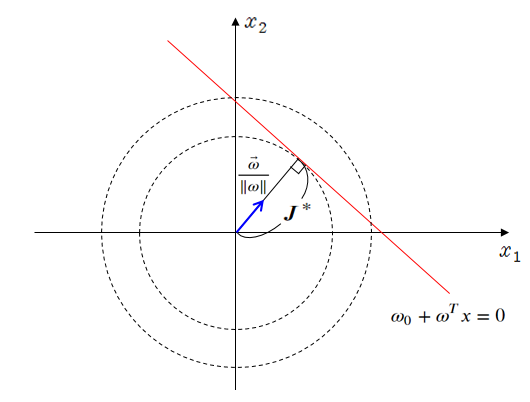

$$ \begin{align} \vec x^* & =J^{*}\frac{\vec \omega}{\lVert \omega \rVert} \\ \\ \omega_0 + \omega^Tx & = \omega_0 + \omega^T\left(J^{*}\frac{\omega}{\lVert \omega \rVert}\right) \\ & = \omega_0 + J^{*}\lVert \omega \rVert = 0 \\ \\ \therefore J^{*} & = -\frac{\omega_0}{\lVert \omega \rVert}\end{align}$$

# Problem 4-1: Feature Extracting from Handwritten Digits

In this problem, we will try to classify handwritten digits. For the sake of simplicity, we simplify this digit classification problem into a binary classification between digit 0 and digit 1.

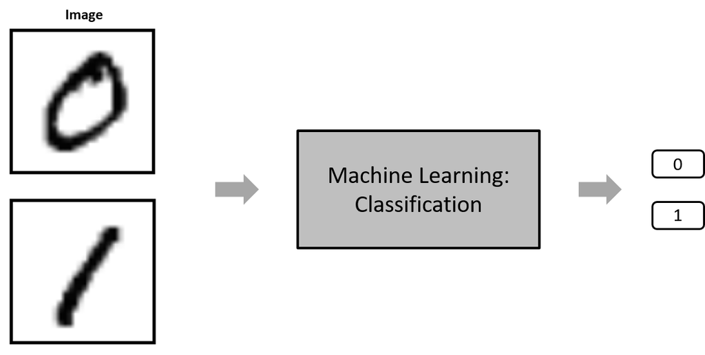

## Step 1. Load the data

| Data | Data dexcription |
| --- | --- |
| 0 | 1000 images (28×28 pixels) of handwritten digit 0 |
| 1 | 1000 images (28×28 pixels) of handwritten digit 1 |

[Download data](https://www.dropbox.com/s/7ljkcn4t08xb1on/data_zero_one.pkl?dl=1)

To read the files in Python, use the following code:

```python
## you do not need to change anyting

import numpy as np
import matplotlib.pyplot as plt
import cvxpy as cvx
%matplotlib inline

from six.moves import cPickle

data = cPickle.load(open('./data_files/data_zero_one.pkl', 'rb'))
data0 = data['0']
data1 = data['1']
```

Here, we will load 1000 of data for ‘0’ and ‘1’, respectively. To display the image use `plt.imshow(img)`.

- Note: make sure you are reading the files correctly. Check by displaying the first few and the last few images in each class.
- Note: calculations are more manageable if you go though and convert each of the pixels in $28\times28$ matrix to a binary value first.

(a) Display the few random images in each class.

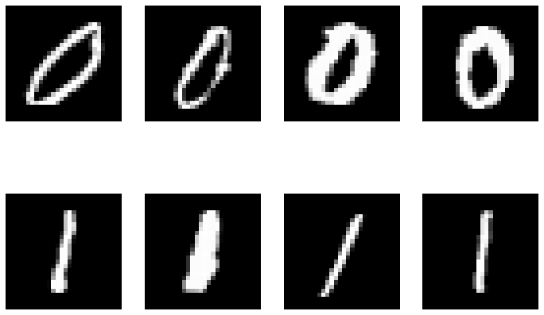

```python
## you do not need to change anyting

plt.figure(figsize = (12, 8))
plt.subplot(2,4,1), plt.imshow(data0[np.random.randint(1000)], 'gray'), plt.axis('off')
plt.subplot(2,4,2), plt.imshow(data0[np.random.randint(1000)], 'gray'), plt.axis('off')
plt.subplot(2,4,3), plt.imshow(data0[np.random.randint(1000)], 'gray'), plt.axis('off')
plt.subplot(2,4,4), plt.imshow(data0[np.random.randint(1000)], 'gray'), plt.axis('off')
plt.subplot(2,4,5), plt.imshow(data1[np.random.randint(1000)], 'gray'), plt.axis('off')
plt.subplot(2,4,6), plt.imshow(data1[np.random.randint(1000)], 'gray'), plt.axis('off')
plt.subplot(2,4,7), plt.imshow(data1[np.random.randint(1000)], 'gray'), plt.axis('off')
plt.subplot(2,4,8), plt.imshow(data1[np.random.randint(1000)], 'gray'), plt.axis('off')
plt.show()
```

(b) Convert each of the pixels in $28×28$ matrix to a binary value.

```python
## you do not need to change anyting

data0 = data0 > 125
data1 = data1 > 125
```

## Step 2. Extract features

In machine learning and pattern recognition, a feature is an individual measurable property or characteristic of a phenomenon being observed. Choosing informative, discriminating and independent features from raw data (or input) is a crucial step for effective algorithms in pattern recognition, classification and regression.

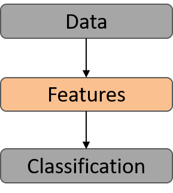

Now we must select the own ‘features’ from image data to detect digit 0 and digit 1. Two features are recommended as follows:

(a) Feature 1: the total average pixels located at the center of the image (`img[10:20,10:20]`).

```python
## your code here
```

(b) Feature 2: the total average pixels over the entire image.

```python
## your code here
```

(c) Include the ones as the bias term.

$$\phi(x) = \begin{bmatrix} 1 \\ \text{feature1}\\ \text{feature2} \end{bmatrix} \quad \implies \quad X \; (\text{or } \Phi) = \begin{bmatrix} \phi_1^T\\ \vdots \\ \phi_{1000}^T \\ \phi_{1001}^T \\ \vdots \\ \phi_{2000}^T \end{bmatrix}$$

You should end up with a $2000\times3$ input matrix with the first $1000$ rows correspond to all of the ‘`data0`’ and the second 1000 rows correspond to all of the given ‘`data1`’. This matrix is matrix $X$ (or $\Phi$) which we learned in a class.

```python
## your code here
```

## Step 3. Plot the features of data

```python
## your code here
```

# Solution 4-1: Feature Extracting from Handwritten Digits

In this problem, we will try to classify handwritten digits. For the sake of simplicity, we simplify this digit classification problem into a binary classification between digit 0 and digit 1.

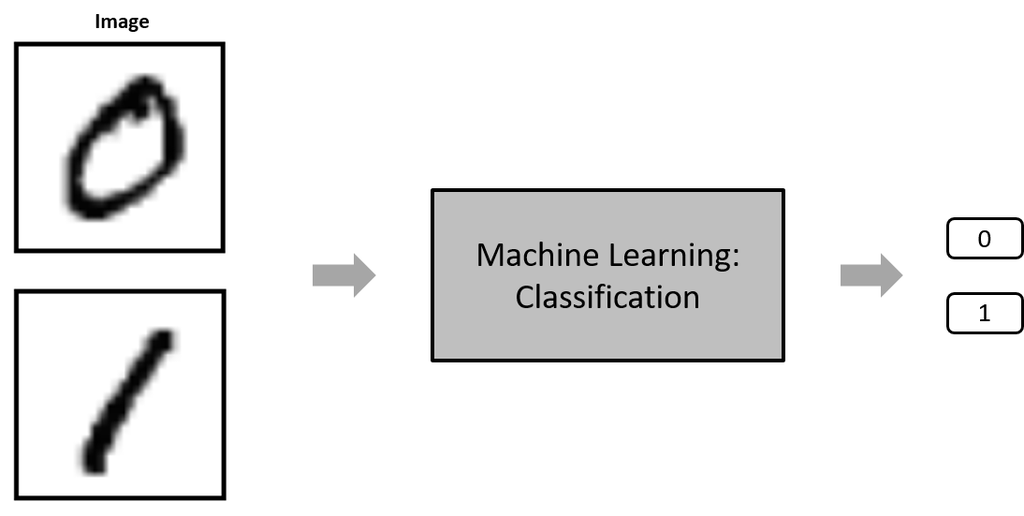

## Step 1. Load the data

| Data | Data dexcription |
| --- | --- |
| 0 | 1000 images (28×28 pixels) of handwritten digit 0 |
| 1 | 1000 images (28×28 pixels) of handwritten digit 1 |

[Download data](https://www.dropbox.com/s/7ljkcn4t08xb1on/data_zero_one.pkl?dl=1)

To read the files in Python, use the following code:

```python
import matplotlib.pyplot as plt
from six.moves import cPickle
data = cPickle.load(open('./data_files/data.pkl', 'rb'))
data0 = data['0']
data1 = data['1']
```

Here, we will load 1000 of data for ‘0’ and ‘1’, respectively. To display the image use `plt.imshow(img)`.

- Note: make sure you are reading the files correctly. Check by displaying the first few and the last few images in each class.
- Note: calculations are more manageable if you go though and convert each of the pixels in $28\times28$ matrix to a binary value first.

(a) Display the few random images in each class.

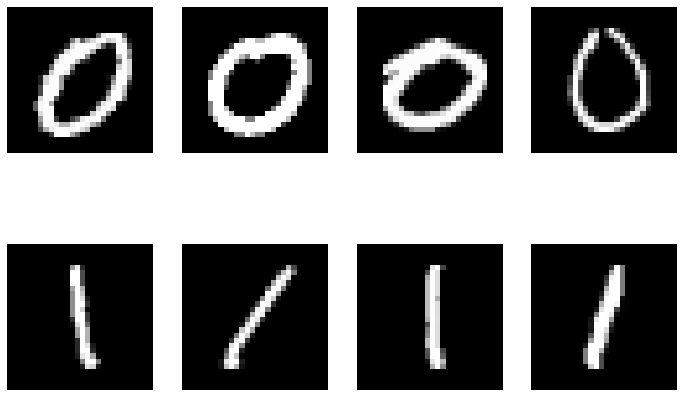

```python
## you do not need to change anyting

plt.figure(figsize = (12, 8))
plt.subplot(2,4,1), plt.imshow(data0[np.random.randint(1000)], 'gray'), plt.axis('off')
plt.subplot(2,4,2), plt.imshow(data0[np.random.randint(1000)], 'gray'), plt.axis('off')
plt.subplot(2,4,3), plt.imshow(data0[np.random.randint(1000)], 'gray'), plt.axis('off')
plt.subplot(2,4,4), plt.imshow(data0[np.random.randint(1000)], 'gray'), plt.axis('off')
plt.subplot(2,4,5), plt.imshow(data1[np.random.randint(1000)], 'gray'), plt.axis('off')
plt.subplot(2,4,6), plt.imshow(data1[np.random.randint(1000)], 'gray'), plt.axis('off')
plt.subplot(2,4,7), plt.imshow(data1[np.random.randint(1000)], 'gray'), plt.axis('off')
plt.subplot(2,4,8), plt.imshow(data1[np.random.randint(1000)], 'gray'), plt.axis('off')
plt.show()
```

(b) Convert each of the pixels in $28×28$ matrix to a binary value.

```python
## you do not need to change anyting

data0 = data0 > 125
data1 = data1 > 125
```

## Step 2. Extract features

In machine learning and pattern recognition, a feature is an individual measurable property or characteristic of a phenomenon being observed. Choosing informative, discriminating and independent features from raw data (or input) is a crucial step for effective algorithms in pattern recognition, classification and regression.

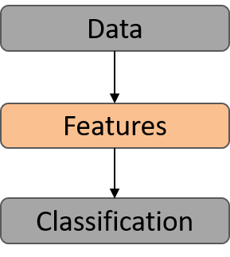

Now we must select the own ‘features’ from image data to detect digit 0 and digit 1. Two features are recommended as follows:

(a) Feature 1: the total average pixels located at the center of the image (`img[10:20,10:20]`).

```python
## your code here
```

```python
## The solution

feature0_1 = np.mean(data0[:,10:20,10:20], axis=(1, 2)).reshape(-1, 1)
feature1_1 = np.mean(data1[:,10:20,10:20], axis=(1, 2)).reshape(-1, 1)
```

(b) Feature 2: the total average pixels over the entire image.

```python
## your code here
```

```python
## The solution


feature0_2 = np.mean(data0, axis=(1, 2)).reshape(-1, 1)
feature1_2 = np.mean(data1, axis=(1, 2)).reshape(-1, 1)
```

(c) Include the ones as the bias term.

$$\phi(x) = \begin{bmatrix} 1 \\ \text{feature1}\\ \text{feature2} \end{bmatrix} \quad \implies \quad X \; (\text{or } \Phi) = \begin{bmatrix} \phi_1^T\\ \vdots \\ \phi_{1000}^T \\ \phi_{1001}^T \\ \vdots \\ \phi_{2000}^T \end{bmatrix}$$

You should end up with a $2000\times3$ input matrix with the first $1000$ rows correspond to all of the ‘`data0`’ and the second 1000 rows correspond to all of the given ‘`data1`’. This matrix is matrix $X$ (or $\Phi$) which we learned in a class.

```python
## your code here
```

[output not shown]

```python
## The solution
X0 = np.hstack([np.ones([1000, 1]), feature0_1, feature0_2])
X1 = np.hstack([np.ones([1000,1]), feature1_1, feature1_2])
X = np.vstack([X0, X1])

print(X.shape)
```

```
(2000, 3)
```

## Step 3. Plot the features of data

Plot the features to see if classes are separable. The expected plot is the following:

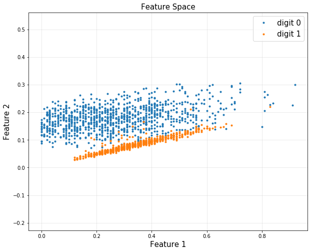

```python
## your code here
```

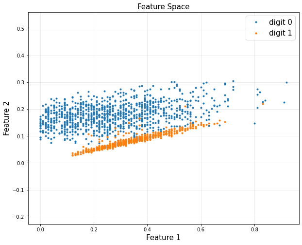

```python
## Ths solution
plt.figure(figsize = (10, 8))
plt.title('Feature Space', fontsize = 15)
plt.plot(feature0_1, feature0_2, '.', label = 'digit 0')
plt.plot(feature1_1, feature1_2, '.', label = 'digit 1')
plt.grid(alpha = 0.3)
plt.legend(fontsize = 15)
plt.xlabel('Feature 1', fontsize = 15)
plt.ylabel('Feature 2', fontsize = 15)
plt.axis('equal')
plt.show()
```

# Problem 4-2: Digit classification with Perceptron

We would like to use the perceptron algorithm to classify digit 0 and digit 1 in the training set.

## Step 1. Initialization

You have to initialize $\omega$ . We usually set $\omega$ to a zero vector as an initial guess

```python
## your code here
```

## Step 2. Update $\omega$

We update $\omega$ when the prediction is wrong. The update rule is the following:

$$ \omega \leftarrow \omega + y \cdot x$$

We will repeat the same iteration for the number of data points. Here’s a pseudo code:

```
For k = 1:100 {
      For j = 1:100 {
            i = random integer selection between 1 and 2000
            compute yhat(i)
            if yhat(i) is wrong {
                w = w + y(i)x(i)
            }
    }
}
```

For every $k$'s iteration, count and store how many predictions are wrong to see if your classifier converges to somewhere or not.

```python
## your code here
```

## Step 3. Plot the result

Second, plot the classifier (decision boundary). Note that the decision boundary is given:

$$\omega_1 x_1 + \omega_2x_2 + \omega_0 = 0$$

```python
## your code here
```

# Solution 4-2: Digit classification with Perceptron

We would like to use the perceptron algorithm to classify digit 0 and digit 1 in the training set.

## Step 1. Initialization

You have to initialize $\omega$ . We usually set $\omega$ to a zero vector as an initial guess.

```python
## your code here
```

```python
## The solution
X0 = np.hstack([np.ones([data0.shape[0], 1]), feature0_1, feature0_2])
X1 = np.hstack([np.ones([data1.shape[0], 1]), feature1_1, feature1_2])
X = np.vstack([X0, X1])
X = np.asmatrix(X)

y = np.vstack([np.ones([1000, 1]), -np.ones([1000, 1])])
y = np.asmatrix(y)

# Initialize w
w = np.zeros([3, 1])
w = np.asmatrix(w)
```

## Step 2. Update $\omega$

We update $\omega$ when the prediction is wrong. The update rule is the following:

$$ \omega \leftarrow \omega + y \cdot x$$

We will repeat the same iteration for the number of data points. Here’s a pseudo code:

```
For k = 1:100 {
      For j = 1:100 {
            i = random integer selection between 1 and 2000
            compute yhat(i)
            if yhat(i) is wrong {
                w = w + y(i)x(i)
            }
    }
}
```

For every $k$'s iteration, count and store how many predictions are wrong to see if your classifier converges to somewhere or not.

```python
## your code here
```

```python
## The solution
cp = []

n_iter = y.shape[0]
for k in range(100):
    cp.append(np.sum(np.sign(X*w) == y))
    for i in range(100):
        idx = np.random.randint(2000)
        if y[idx,0] != np.sign(X[idx,:]*w)[0,0]:
            w += y[idx,0]*X[idx,:].T
```

## Step 3. Plot the result

You are asked to plot two graphs. First, plot the number of wrong predictions with respect to every $k$'s iteration. The graph is expected as follows:

Second, plot the classifier (decision boundary). Note that the decision boundary is given:

$$\omega_1 x_1 + \omega_2x_2 + \omega_0 = 0$$

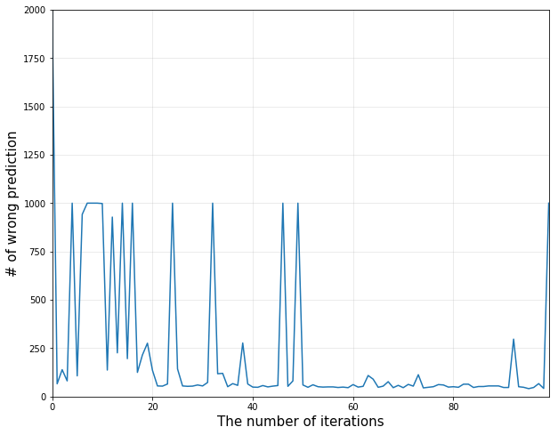

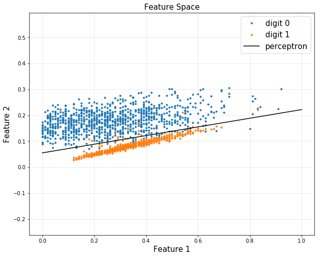

```python
## your code here
```

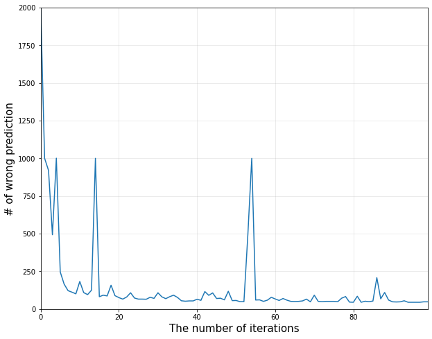

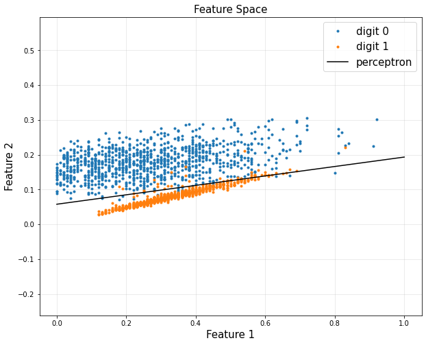

```python
## The solution
x1p = np.linspace(0,1).reshape(-1,1)
x2p = - w[1,0]/w[2,0]*x1p - w[0,0]/w[2,0]

plt.figure(figsize = (10, 8))
plt.plot(2000 - np.array(cp))
plt.xlabel('The number of iterations', fontsize = 15)
plt.ylabel('# of wrong prediction', fontsize = 15)
plt.axis([0, 99, 0, 2000])
plt.grid(alpha = 0.3)

plt.figure(figsize = (10, 8))
plt.title('Feature Space', fontsize=15)
plt.plot(feature0_1, feature0_2, '.', label = 'digit 0')
plt.plot(feature1_1, feature1_2, '.', label = 'digit 1')
plt.plot(x1p, x2p, c = 'k', label = 'perceptron')
plt.plot()
plt.grid(alpha = 0.3)
plt.legend(fontsize = 15)
plt.xlabel('Feature 1', fontsize = 15)
plt.ylabel('Feature 2', fontsize = 15)
plt.axis('equal')
plt.show()
```

# Problem 4-3: Digit Classification with SVM

We would like to use the SVM algorithm to classify digit 0 and digit 1 in the training set.

## Step 1. Define variables

Find a classifier using the support vector machine which is equivalent to solving the following optimization problem:

$$\begin{align*} \text{minimize } & \lVert \omega \rVert_2 + \gamma(1^Tu + 1^Tv)\\ \text{subject to }& \\ & X_0^T \omega \geq 1 - u\\ & X_1^T \omega \leq - (1-v)\\ & u \geq 0\\ & v \geq 0 \end{align*}$$

Here, $X_0$ and $X_1$ are $1000\times3$ matrix for each class. You can divide the above matrix $X$ into two parts to reuse it.

```python
## your code here
```

## Step 2. CVXPY

Run CVXPY to find $\omega$.

```python
## your code here
#
```

## Step 3. Plot the result

Now you have an optimal $\omega$ . Plot a decision boundary. Note that our decision boundary is defined as follows:

$$ \omega_1 x_1 + \omega_2 x_2 + \omega_0 = 0$$

```python
## your code here
#
```

# Solution 4-3: Digit classification with SVM

We would like to use the SVM algorithm to classify digit 0 and digit 1 in the training set.

## Step 1. Define variables

Find a classifier using the support vector machine which is equivalent to solving the following optimization problem:

$$\begin{align*} \text{minimize } & \lVert \omega \rVert_2 + \gamma(1^Tu + 1^Tv)\\ \text{subject to }& \\ & X_0^T \omega \geq 1 - u\\ & X_1^T \omega \leq - (1-v)\\ & u \geq 0\\ & v \geq 0 \end{align*}$$

Here, $X_0$ and $X_1$ are $1000\times3$ matrix for each class. You can divide the above matrix $X$ into two parts to reuse it.

```python
## your code here
```

```python
## The solution
X0 = np.hstack([np.ones([data0.shape[0], 1]), feature0_1, feature0_2])
X1 = np.hstack([np.ones([data1.shape[0], 1]), feature1_1, feature1_2])
X = np.vstack([X0, X1])
X = np.asmatrix(X)
```

## Step 2. CVXPY

Run CVXPY to find $\omega$.

```python
## your code here
```

```python
## The solution
import cvxpy as cvx

g = 1

w = cvx.Variable((3, 1))
u = cvx.Variable((1000, 1))
v = cvx.Variable((1000, 1))

obj = cvx.Minimize(cvx.norm(w, 2) + g*(np.ones([1, 1000])*u + np.ones([1, 1000])*v))
const = [X0*w >= 1-u, X1*w <= -(1-v), u >= 0, v >= 0 ]
prob = cvx.Problem(obj, const).solve()

w = w.value

print(w)
```

```
[[-2.20668059]
 [-9.6033403 ]
 [49.10229647]]
```

[output not shown]

## Step 3. Plot the result

Now you have an optimal $\omega$ . Plot a decision boundary. Note that our decision boundary is defined as follows:

$$ \omega_1 x_1 + \omega_2 x_2 + \omega_0 = 0$$

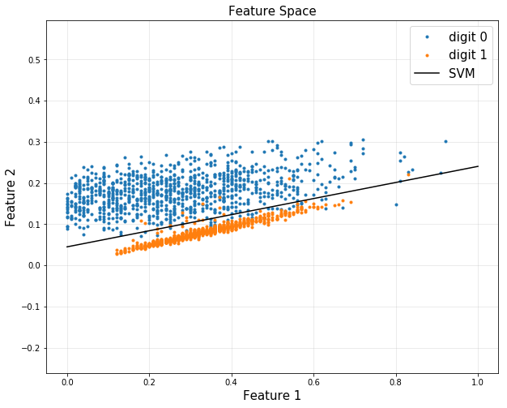

```python
## your code here
```

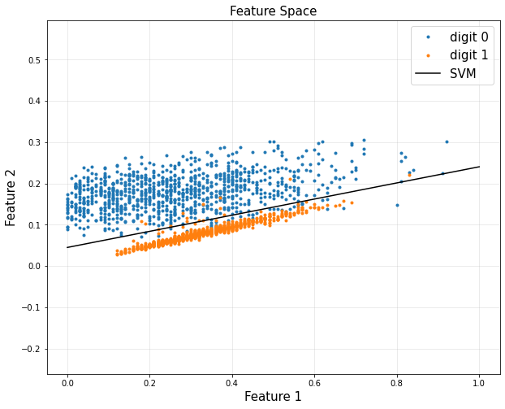

```python
## The solution
xp = np.linspace(0, 1)
yp = - w[1,0]/w[2,0]*xp - w[0,0]/w[2,0]

plt.figure(figsize = (10, 8))
plt.title('Feature Space', fontsize=15)
plt.plot(feature0_1, feature0_2, '.', label = 'digit 0')
plt.plot(feature1_1, feature1_2, '.', label = 'digit 1')
plt.plot(xp, yp, c = 'k', label = 'SVM')
plt.plot()
plt.grid(alpha = 0.3)
plt.legend(fontsize = 15)
plt.xlabel('Feature 1', fontsize = 15)
plt.ylabel('Feature 2', fontsize = 15)
plt.axis('equal')
plt.show()
```

# Problem 5

[8pt] Consider the binary classification task that consists of the following points:

$$ \begin{align*} \mathcal{C}_1 &= \left\{ \begin{bmatrix} 1 \\1\end{bmatrix}, \begin{bmatrix} 1 \\-1\end{bmatrix} \right\}\\ \mathcal{C}_0 &= \left\{ \begin{bmatrix} -1 \\1\end{bmatrix}, \begin{bmatrix} -1 \\-1\end{bmatrix} \right\} \end{align*} $$

$g(x) = \omega_0 + \omega_1 x_1 + \omega_2 x_2 = 0$ is a generic expression of a linear classification boundary. Show that the linear classification boundary by the SVM approach is $x_1 = 0$

# Solution 5

SVM makes margin (minimum distance from boundary) maximize. First, assumpt that $g(x)$ is a linear line with positive slope. Then,

$$\begin{align} g \left(x \right) = \omega_0 + \omega_1 x_1 + \omega_2 x_2 = 0 \quad \Longrightarrow \quad x_2 = - \frac{\omega_1}{\omega_2} - \frac{\omega_0}{\omega_2} \end{align}$$

To make this line as positive slope, $- \frac{\omega_1}{\omega_2} > 1, \quad \therefore \omega_1 < -\omega_2 $

In this assumption, $(1,1)$ and $(-1,-1)$ have to become support vectors. So each distance from boundary line have to become same.

$$\begin{align} d &= \frac{\left\vert \omega_0 + \omega_1 + \omega_2 \right\vert}{\sqrt{\omega_1^2 + \omega_2^2}} = \frac{\left\vert \omega_0 - \omega_1 - \omega_2 \right\vert}{\sqrt{\omega_1^2 + \omega_2^2}} \\ & \approx \left\vert \omega_0 + \omega_1 + \omega_2 \right\vert = \left\vert \omega_0 - \omega_1 - \omega_2 \right\vert \\\\ & \therefore \omega_1 = \omega_2 \quad or \quad \omega_0 = 0 \end{align}$$

But $\omega_1 = \omega_2$ case violate $\omega_1 < -\omega_2$ condition, so $\omega_0 = 0$

Now the problem becomes

$$\begin{align} \text{maximize} \quad \frac{\left\vert \omega_1 + \omega_2 \right\vert}{\sqrt{\omega_1^2 + \omega_2^2}} \end{align}$$

$$\begin{align} \left\vert \omega_1 + \omega_2 \right\vert = \sqrt{\left(\omega_1 + \omega_2 \right)^2} = \sqrt{\omega_1^2 + 2\omega_1\omega_2 + \omega_2^2} < \sqrt{\omega_1^2 + \omega_2^2} \quad \left(\because 2\omega_1\omega_2 < 0 \right) \end{align}$$

The maximum distance is 1, when $\omega_1 = 0$ or $\omega_2 = 0$.

If $\omega_1 = 0$, $g(x): x_2 = 0$ but this cannot classify those points. So $\omega_2 = 0$ and $g(x): x_1 = 0$

# Problem 09: Multiclass class classification with SVM

[Classification with more than two classes]

We learned about a binary classification in class (SVM). However, we have to deal with multi-class classifications for some cases. I provide three groups of data in the following python code. Create your own algorithms in python to find linear classification surfaces and classes that each data belongs to.

(hint: use binary classification algorithms and extend it to multi-class classification problems)

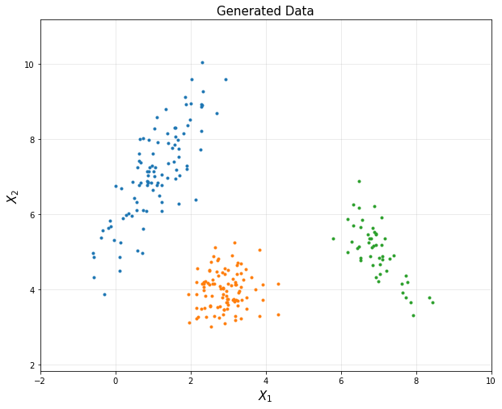

```python
import numpy as np
import matplotlib.pyplot as plt
%matplotlib inline

## generate three simulated clusters

mu1 = np.array([1, 7])
SIGMA1 = 0.8*np.array([[1, 1.5],
                       [1.5, 3]])
X1 = np.random.multivariate_normal(mu1, SIGMA1, 100)

mu2 = np.array([3, 4])
SIGMA2 = 0.3*np.array([[1, 0],
                       [0, 1]])
X2 = np.random.multivariate_normal(mu2, SIGMA2, 100)

mu3 = np.array([7, 5])
SIGMA3 = 0.3*np.array([[1, -1],
                       [-1, 2]])
X3 = np.random.multivariate_normal(mu3, SIGMA3, 50)

plt.figure(figsize = (10, 8))
plt.title('Generated Data', fontsize=15)
plt.plot(X1[:,0], X1[:,1], '.')
plt.plot(X2[:,0], X2[:,1], '.')
plt.plot(X3[:,0], X3[:,1], '.')
plt.xlabel('$X_1$', fontsize = 15)
plt.ylabel('$X_2$', fontsize = 15)
plt.axis('equal')
plt.grid(alpha = 0.3)
plt.axis([-2, 10, 1, 12])
plt.show()
```

```python
# your code here
```

# Solution 09: Multiclass class classification with SVM

[Classification with more than two classes]

We learned about a binary classification in class (SVM). However, we have to deal with multi-class classifications for some cases. I provide three groups of data in the following python code. Create your own algorithms in python to find linear classification surfaces and classes that each data belongs to.

(hint: use binary classification algorithms and extend it to multi-class classification problems)

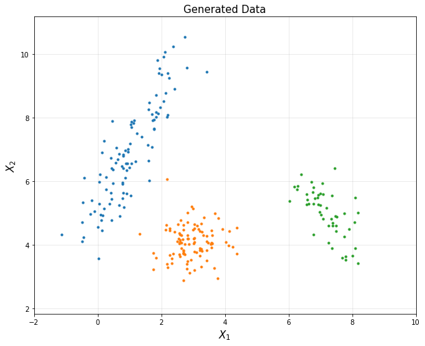

```python
import numpy as np
import matplotlib.pyplot as plt
%matplotlib inline

## generate three simulated clusters

mu1 = np.array([1, 7])
SIGMA1 = 0.8*np.array([[1, 1.5],
                       [1.5, 3]])
X1 = np.random.multivariate_normal(mu1, SIGMA1, 100)

mu2 = np.array([3, 4])
SIGMA2 = 0.3*np.array([[1, 0],
                       [0, 1]])
X2 = np.random.multivariate_normal(mu2, SIGMA2, 100)

mu3 = np.array([7, 5])
SIGMA3 = 0.3*np.array([[1, -1],
                       [-1, 2]])
X3 = np.random.multivariate_normal(mu3, SIGMA3, 50)

plt.figure(figsize = (10, 8))
plt.title('Generated Data', fontsize=15)
plt.plot(X1[:,0], X1[:,1], '.')
plt.plot(X2[:,0], X2[:,1], '.')
plt.plot(X3[:,0], X3[:,1], '.')
plt.xlabel('$X_1$', fontsize = 15)
plt.ylabel('$X_2$', fontsize = 15)
plt.axis('equal')
plt.grid(alpha = 0.3)
plt.axis([-2, 10, 1, 12])
plt.show()
```

[output not shown]

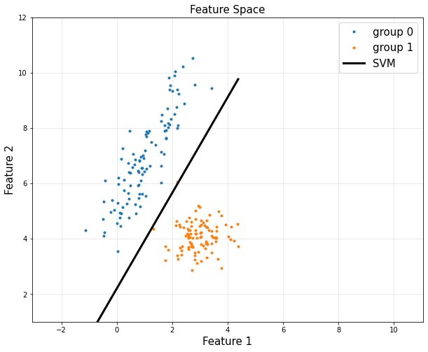

[output not shown]

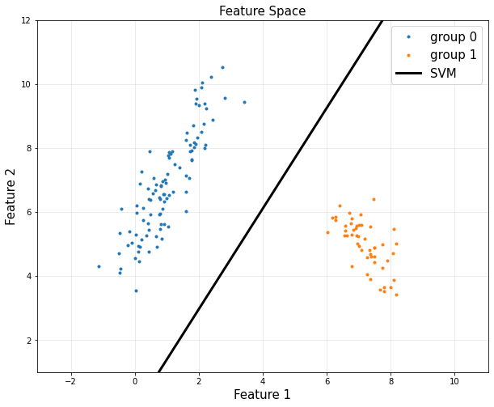

[output not shown]

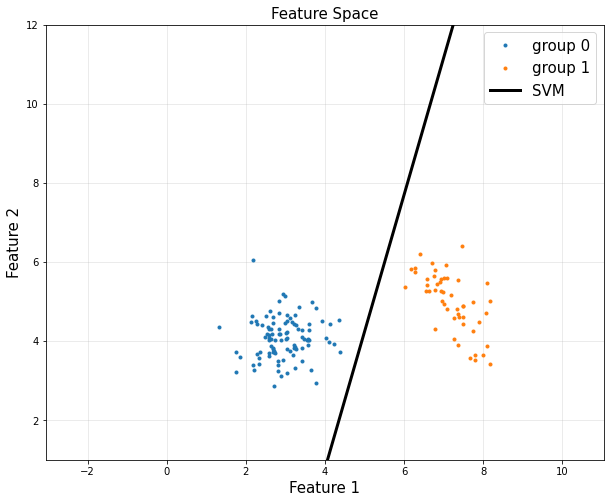

[output not shown]

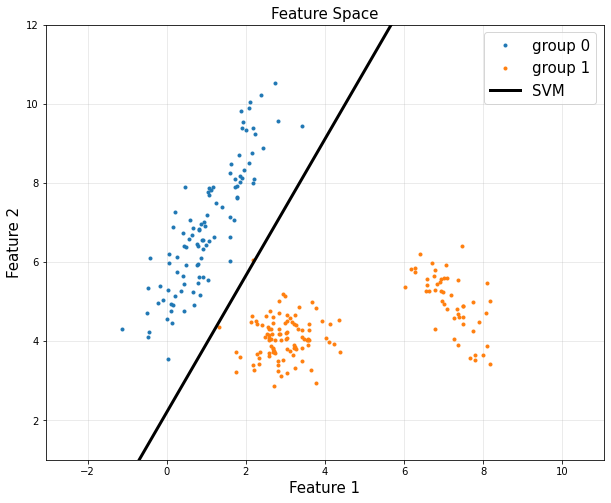

[output not shown]

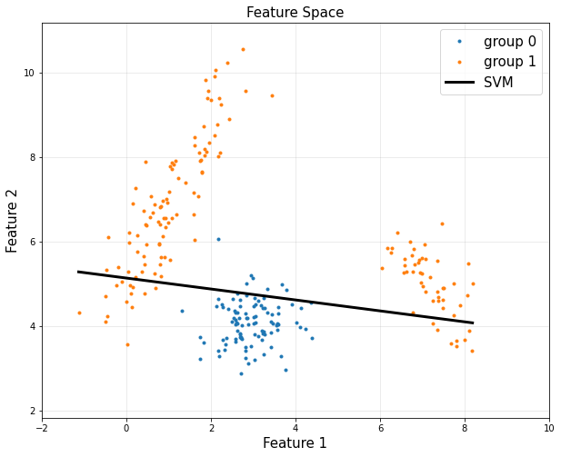

[output not shown]

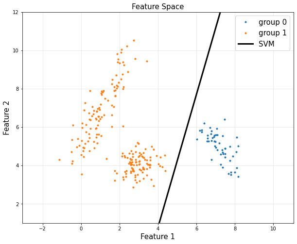

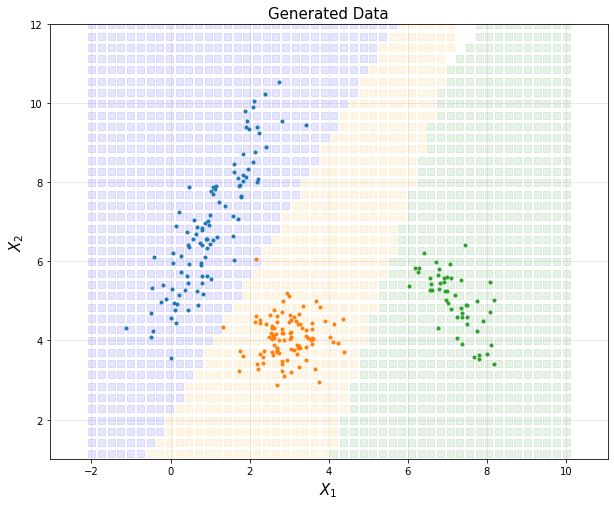

```python
## The solution
import cvxpy as cvx

def my_svm(data0, data1):
    X0_shape = data0.shape[0]
    X1_shape = data1.shape[0]

    X0 = np.hstack([np.ones([X0_shape, 1]), data0])
    X1 = np.hstack([np.ones([X1_shape, 1]), data1])
    X = np.vstack([X0, X1])
    X = np.asmatrix(X)

    g = 1

    w = cvx.Variable([3, 1])
    u = cvx.Variable([X0_shape, 1])
    v = cvx.Variable([X1_shape, 1])

    obj = cvx.Minimize(cvx.norm(w, 2) + g*(np.ones([1, X0_shape])*u + np.ones([1, X1_shape])*v))
    const = [X0*w >= 1-u, X1*w <= -(1-v), u >= 0, v >= 0 ]
    prob = cvx.Problem(obj, const).solve()

    w = w.value

    # Just for Plotting
    max_point = np.max(np.hstack([X0[:,1], X1[:,1]]))
    min_point = np.min(np.hstack([X0[:,1], X1[:,1]]))

    xp = np.linspace(min_point, max_point)
    yp = - w[1,0]/w[2,0]*xp - w[0,0]/w[2,0]

    plt.figure(figsize = (10, 8))
    plt.title('Feature Space', fontsize = 15)
    plt.plot(X0[:,1], X0[:,2], '.', label = 'group 0')
    plt.plot(X1[:,1], X1[:,2], '.', label = 'group 1')
    plt.plot(xp, yp, c = 'k', linewidth = 3, label = 'SVM')
    plt.plot()
    plt.legend(fontsize=15)
    plt.xlabel('Feature 1', fontsize = 15)
    plt.ylabel('Feature 2', fontsize = 15)
    plt.axis('equal')
    plt.grid(alpha = 0.3)
    plt.axis([-2, 10, 1, 12])
    plt.show()

    return w
w_1_2 = my_svm(X1, X2)
w_1_3 = my_svm(X1, X3)
w_2_3 = my_svm(X2, X3)
# one vs. rest
w_1_23 = my_svm(X1, np.vstack([X2, X3]))
w_2_13 = my_svm(X2, np.vstack([X1, X3]))
w_3_12 = my_svm(X3, np.vstack([X1, X2]))
# only one vs one classifiers are used

def class_check(x1, x2):
    point = np.asmatrix([[1, x1, x2]])

    isClass1 = [(point*w_1_2 > 0)[0,0], (point*w_1_3 > 0)[0,0]]
    isClass2 = [(point*w_1_2 < 0)[0,0], (point*w_2_3 > 0)[0,0]]
    isClass3 = [(point*w_1_3 < 0)[0,0], (point*w_2_3 < 0)[0,0]]

    if all(x == True for x in isClass1):
        return 1
    elif all(x == True for x in isClass2):
        return 2
    elif all(x == True for x in isClass3):
        return 3
    else:
        return 0

plt.figure(figsize = (10, 8))
plt.xlim((-2,10))
plt.ylim((-2,12))
x1_range = np.linspace(-2, 10, 50)
x2_range = np.linspace(-2, 12, 50)

for x1 in x1_range:
    for x2 in x2_range:
        label = class_check(x1, x2)

        if label == 1:
            color = 'blue'
            alpha = 0.1
        elif label == 2:
            color = 'orange'
            alpha = 0.1
        elif label == 3:
            color = 'green'
            alpha = 0.1
        else:
            alpha = 0.0

        plt.plot(x1, x2, 's', alpha = alpha, color = color, markersize = 7)

plt.title('Generated Data', fontsize = 15)
plt.plot(X1[:,0], X1[:,1], '.')
plt.plot(X2[:,0], X2[:,1], '.')
plt.plot(X3[:,0], X3[:,1], '.')
plt.xlabel('$X_1$', fontsize = 15)
plt.ylabel('$X_2$', fontsize = 15)
plt.axis('equal')
plt.grid(alpha = 0.3)
plt.axis([-2, 10, 1, 12])
plt.show()
```

# Problem 11

For the XOR problem, write your own answer to the below questions. The truth table of $x_1$ XOR $x_2$ shows that it outputs 1 whenever the inputs differ.

| $x_1$ | $x_2$ | output |
| --- | --- | --- |
| -1 | -1 | -1 |
| 1 | -1 | 1 |
| -1 | 1 | 1 |
| 1 | 1 | -1 |

(a) [3pt] Plot the two classes data and show that the data is not linearly separable.

```python
# your code here
#
```

(b) [5pt] Discuss whether mapping $\phi(x) = \begin{bmatrix} x_1 - x_2 \\ x_1x_2 \\ x_1+x_2 \end{bmatrix}$ can solve the XOR problem or not. If it can, plot the data on higher dimensional space and find hyperplane. (Use the SVM classifier, and you do not need to visualize the classification hyperplane)

```python
#your code here
#
```

# Solution 11

For the XOR problem, write your own answer to the below questions. The truth table of $x_1$ XOR $x_2$ shows that it outputs 1 whenever the inputs differ.

| $x_1$ | $x_2$ | output |
| --- | --- | --- |
| -1 | -1 | -1 |
| 1 | -1 | 1 |
| -1 | 1 | 1 |
| 1 | 1 | -1 |

(a) [3pt] Plot the two classes data and show that the data is not linearly separable.

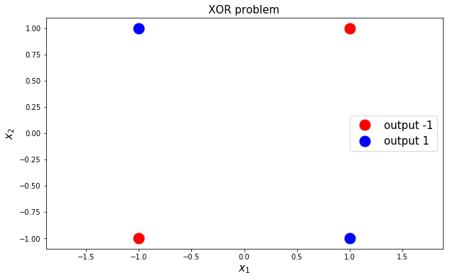

```python
## your code here
import numpy as np
import matplotlib.pyplot as plt

%matplotlib inline

x1 = np.array([-1, 1, -1, 1]).reshape(-1, 1)
x2 = np.array([-1, -1, 1, 1]).reshape(-1, 1)

C1 = np.where(x1 == x2)
C0 = np.where(x1 != x2)

plt.figure(figsize = (10 ,6))
plt.title("XOR problem", fontsize=15)
plt.plot(x1[C1] ,x2[C1], 'ro', markersize =15, label = 'output -1')
plt.plot(x1[C0] ,x2[C0], 'bo', markersize =15,  label='output 1')
plt.axis([-2, 2, -2, 2])
plt.axis('equal')
plt.xlabel("$x_1$", fontsize=15)
plt.ylabel("$x_2$", fontsize=15)
plt.legend(fontsize = 15)
plt.show()
```

(b) [5pt] Discuss whether mapping $\phi(x) = \begin{bmatrix} x_1 - x_2 \\ x_1x_2 \\ x_1+x_2 \end{bmatrix}$ can solve the XOR problem or not. If it can, plot the data on higher dimensional space and find hyperplane. (Use the SVM classifier, and you do not need to visualize the classification hyperplane)

$$\phi(x) = \begin{bmatrix} x_1 - x_2 \\ x_1x_2 \\ x_1+x_2 \end{bmatrix} = \begin{bmatrix} X_1 \\ X_2 \\ X_3 \end{bmatrix}$$

we can define $g(X) = \omega^T X=0$

$$ g(X) = \omega_1 X_1 + \omega_2 X_2 + \omega_3 X_3 =0 $$

also, we can set the contraints

when $x_1$ and $x_2$ have the same value(i.e. output = -1), $$x_1-x_2 = 0,\; x_1x_2 =1, \; x_1+x_2 = \lvert 2 \rvert $$

when $x_1$ and $x_2$ have the same value(i.e. output = 1), $$x_1-x_2 = \lvert 2 \rvert, \; x_1x_2 = -1, \; x_1+x_2 =0 $$

$$\implies g(X) = \omega_1 \lvert 2 \rvert - \omega_2 \leq 0$$

**we can solve the XOR problem because there are many $\omega$ to be satisfied with these constraints**

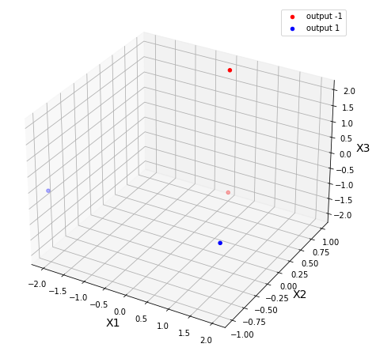

```python
from matplotlib import cm
from mpl_toolkits.mplot3d import Axes3D

x1_1 = x1[C1].reshape

X_1 = x1 - x2
X_2 = x1*x2
X_3 = x1 + x2

X1 = np.hstack([X_1[C1].reshape(-1,1), X_2[C1].reshape(-1,1), X_3[C1].reshape(-1,1)])
X0 =  np.hstack([X_1[C0].reshape(-1,1), X_2[C0].reshape(-1,1), X_3[C0].reshape(-1,1)])

fig = plt.figure(figsize=(20,8))
ax = fig.add_subplot(1, 2, 1, projection='3d')
ax.scatter(X1[:, 0], X1[:, 1], X1[:, 2], c='r', marker='o', label = 'output -1')
ax.scatter(X0[:, 0], X0[:, 1], X0[:, 2], c='b', marker='o', label = 'output 1')
ax.set_xlabel('X1', fontsize=14)
ax.set_ylabel('X2', fontsize=14)
ax.set_zlabel('X3', fontsize=14)
plt.legend()
plt.show()
```

```python
#  find hyperplane by using the SVM classifier

import cvxpy as cvx

X = np.hstack([x1 - x2, x1*x2, x1+x2])
X = np.asmatrix(X)
y = np.array([-1, 1, 1, -1]).reshape(-1, 1)

w = cvx.Variable([3,1])
d = cvx.Variable([4,1])

g = 2

obj = cvx.Minimize(cvx.norm(w,2) + g*(np.ones([1,4])*d))
const = [cvx.multiply(y, X*w) >= 1-d, d >= 0]
prob = cvx.Problem(obj, const).solve()

w = w.value

print("the actual output : \n", y, "\n")
print("the prediction of SVM classification : \n", X*w, "\n")

print('omega : \n', w, "\n")
print("Hyperplane :")
print("g(x) = {}*X2 = 0".format(int(w[1,0])))
```

```
the actual output :
 [[-1]
 [ 1]
 [ 1]
 [-1]]

the prediction of SVM classification :
 [[-1.]
 [ 1.]
 [ 1.]
 [-1.]]

omega :
 [[ 0.]
 [-1.]
 [ 0.]]

Hyperplane :
g(x) = -1*X2 = 0
```

So, the hyperplane is the xz-plane with $x_2 = 0$